# Assess Learning Algorithms

## Machine Learning for Stock Trading

### Part II - Comparative Analysis of Learning Algorithm

**Objective:** In this notebook we will analyze and compare various learnering algotrithms such as Decision Tree Learner, Random Tree Learner, and Bag Learner. The goal is to predict what the return for the MSCI Emerging Markets (EM) index will be on the basis of the other index returns.

```python
import numpy as np
import math
import LinRegLearner as lrl
import sys
import DTLearner as dt
import RTLearner as rt
import BagLearner as bl
import InsaneLearner as il
import matplotlib.pyplot as plt
import time
```

**Data Format:** We will use the returns of multiple worldwide indexes for a number of days in history. Y in this case is the last column to the right, and the X values are the remaining columns to the left (except the first column which is the date).

```python
inf = open("./Data/istanbul.csv")
data = np.array([map(float,s.strip().split(',')[1:]) for s in inf.readlines()[1:]])
```

**Experiment 1: Train & Evaluate a Decision Tree Learner:** Train and test a Decision Tree Learner on various leaf sizes. Then compare the root mean squared errors (RMSEs) between the in-sample (training set) and out-of-sample data (test set) to evaluate where overfitting occurs. Train the data and retrieve the RMSEs and correlations for in-sample and out-of-sample data.

```python
np.random.seed(123)
datasize = data.shape[0]
cutoff = int(datasize*0.6)
permutation = np.random.permutation(data.shape[0])
col_permutation = np.random.permutation(data.shape[1]-1)
train_data = data[permutation[:cutoff],:]
# trainX = train_data[:,:-1]
trainX = train_data[:,col_permutation]
trainY = train_data[:,-1]
test_data = data[permutation[cutoff:],:]
# testX = test_data[:,:-1]
testX = test_data[:,col_permutation]
testY = test_data[:,-1]

# create a learner and train it
learner = lrl.LinRegLearner(verbose = True) # create a LinRegLearner
learner.addEvidence(trainX, trainY) # train it
print learner.author()

# evaluate in sample
predY = learner.query(trainX) # get the predictions
rmse = math.sqrt(((trainY - predY) ** 2).sum()/trainY.shape[0])
print
print "In sample results"
print "RMSE: ", rmse
c = np.corrcoef(predY, y=trainY)
print "corr: ", c[0,1]

# evaluate out of sample
predY = learner.query(testX) # get the predictions
rmse = math.sqrt(((testY - predY) ** 2).sum()/testY.shape[0])
print
print "Out of sample results"
print "RMSE: ", rmse
c = np.corrcoef(predY, y=testY)
print "corr: ", c[0,1]
```

```
adeshpande78

In sample results
RMSE:  0.00486807249851
corr:  0.893423143284027

Out of sample results
RMSE:  0.00488047287789
corr:  0.8753537626935582
```

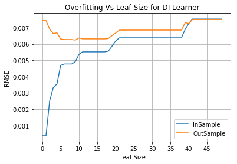

```python
rmse_insample=[]
rmse_outsample=[]
for i in range (50):
    dtlearner = dt.DTLearner(leaf_size = i, verbose =False)
    dtlearner.addEvidence(trainX, trainY)
    predY = dtlearner.query(trainX)
    rmse_insample.append(math.sqrt(((trainY - predY) ** 2).sum() / trainY.shape[0]))
    predY = dtlearner.query(testX)
    rmse_outsample.append(math.sqrt(((testY - predY) ** 2).sum() / testY.shape[0]))

plt.xlabel("Leaf Size")
plt.ylabel("RMSE")
plt.plot(rmse_insample,label="InSample")
plt.plot(rmse_outsample, label="OutSample")
plt.title("Overfitting Vs Leaf Size for DTLearner")
plt.xticks(range(0,50,5))
plt.grid(True)
plt.legend()
plt.show()
```

**Conclusion:** It can be concluded that overfitting decreases with increase in leaf size.

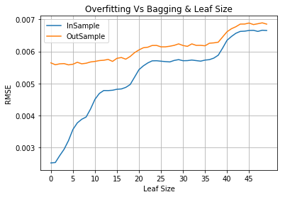

```python
rmse_insample=[]
rmse_outsample=[]

for i in range (50):
    itr_rmse_insample=[]
    itr_rmse_outsample=[]
    for j in range(20):
        bglearner = bl.BagLearner(learner = dt.DTLearner, kwargs = {"leaf_size":i}, bags = 20, boost = False, verbose = False)
        bglearner.addEvidence(trainX, trainY)
        predY = bglearner.query(trainX)
        itr_rmse_insample.append(math.sqrt(((trainY - predY) ** 2).sum() / trainY.shape[0]))
        predY = bglearner.query(testX)
        itr_rmse_outsample.append(math.sqrt(((testY - predY) ** 2).sum() / testY.shape[0]))
    rmse_insample.append(sum(itr_rmse_insample)/20)
    predY = bglearner.query(testX)
    rmse_outsample.append(sum(itr_rmse_outsample)/20)
plt.xlabel("Leaf Size")
plt.ylabel("RMSE")
plt.plot(rmse_insample,label="InSample")
plt.plot(rmse_outsample, label="OutSample")
plt.title("Overfitting Vs Bagging & Leaf Size")
plt.xticks(range(0,50,5))
plt.grid(True)
plt.legend()
plt.show()
```

**Analysis:** This experiment was performed to observe how bagging affect the overfitting in Decision Tree Learners. This experiment uses RMSE to evaluate overfitting of the model. Overfitting occurs when model fits training data. The experiment was carried out on Istanbul dataset and bagging was implemented with 20 bags for each iteration. Dataset was divided into Training set (60%) and Testing set (40%).  
In this experiment RMSE for DT Leaner was calculated for different Leaf Sizes (1 to 50). Since the dataset contains timeseries data, dataset is shuffled to avoid skewing. Random seed of 123 was used shuffling the data. Experiment was repeated 20 times at each leaf to smooth out the observations.  
From below plots it can be observed that bagging does not eliminates the overfitting but it does reduce the overfitting. When compared to previous experiment, it can be noted that with bagging difference between train and test RMSE is not as large and RMSE for InSample data starts between 0.002 and 0.003.

**Conclusion:** It can be concluded that Bagging reduces overfitting but does not eliminate it

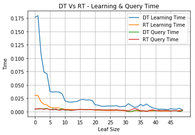

```python
dtTrainTime = []
dtQueryTime = []
dtNodeCnt = []
rtTrainTime = []
rtQueryTime = []
rtNodeCnt = []


for i in range (50):
    dtItrTrainTime = []
    dtItrQueryTime = []
    dtItrNodeCnt = []
    rtItrTrainTime = []
    rtItrQueryTime = []
    rtItrNodeCnt = []
    for j in range(20):
        startTime = time.time()
        dtlearner = dt.DTLearner(leaf_size = i, verbose =False)
        dtlearner.addEvidence(trainX, trainY)
        dtItrTrainTime.append(time.time()-startTime)

        startTime = time.time()
        predY = dtlearner.query(trainX)
        dtItrQueryTime.append(time.time()-startTime)
        dtItrNodeCnt.append(dtlearner.tree.shape[0])

        startTime = time.time()
        rtlearner = rt.RTLearner(leaf_size = i, verbose =False)
        rtlearner.addEvidence(trainX, trainY)
        rtItrTrainTime.append(time.time()-startTime)

        startTime = time.time()
        predY = rtlearner.query(trainX)
        rtItrQueryTime.append(time.time()-startTime)
        rtItrNodeCnt.append(rtlearner.tree.shape[0])

    dtTrainTime.append(sum(dtItrTrainTime)/20)
    dtQueryTime.append(sum(dtItrQueryTime)/20)
    dtNodeCnt.append(sum(dtItrNodeCnt)/20)
    rtTrainTime.append(sum(rtItrTrainTime)/20)
    rtQueryTime.append(sum(rtItrQueryTime)/20)
    rtNodeCnt.append(sum(rtItrNodeCnt)/20)

plt.xlabel("Leaf Size")
plt.ylabel("Time")
plt.plot(dtTrainTime,label="DT Learning Time")
plt.plot(rtTrainTime, label="RT Learning Time")
plt.plot(dtQueryTime,label="DT Query Time")
plt.plot(rtQueryTime, label="RT Query Time")
plt.title("DT Vs RT - Learning & Query Time")
plt.xticks(range(0,50,5))
plt.grid(True)
plt.legend()
plt.show()
```

**Analysis:** This experiment was performed to quantitatively compare "classic" decision trees (DTLearner) versus random trees (RTLearner) to determine which method is better than other. Experiment was performed to measure and compare “Learning and Query Time” and “Tree Size” The experiment was carried out on Istanbul dataset and bagging was not implemented. Dataset was divided into Training set (60%) and Testing set (40%).  
In this experiment Learning & Query Time and Tree Size for DT & RT Leaner was calculated for different Leaf Sizes (1 to 50). Since the dataset contains timeseries data, dataset is shuffled to avoid skewing. Random seed of 123 was used shuffling the data. Experiment was repeated 20 times at each leaf to smooth out the observations.  
Learning and Query Time: For smaller leaf size, learning time for DT Learner is significantly higher as compared to RT Learner. Learning time for DT Learner reduces as leaf size increases and reaches close to RT Learner for leaf size higher than 40. It was also observed that query time for DT Learner and RT Leaner is not significantly different

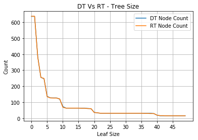

```python
plt.xlabel("Leaf Size")
plt.ylabel("Count")
plt.plot(dtNodeCnt,label="DT Node Count")
plt.plot(rtNodeCnt, label="RT Node Count")
plt.title("DT Vs RT - Tree Size")
plt.xticks(range(0,50,5))
plt.grid(True)
plt.legend()
plt.show()
```

**Tree Size:** There is not significant difference in the tree size created by both DT and RT learner irrespective of the leaf size.

**Conclusion:** It can be concluded that for smaller leaf size RT Learner learns faster as compared to DT Leaner. For large leaf size learning time, query time and tree size is similar for both learner.